# COVID19 - Forecast and predictions using a time dependent SEIR model for the Veneto Region

Paolo Girardi

07 Aprile, 2020

This work is licensed under a [Creative Commons Attribution-NonCommercial 4.0 International License](http://creativecommons.org/licenses/by-nc/4.0/).

# Disclaimer

- We want to investigate the evolution of the coronavirus pandemic in the Veneto Region from a statistical perspective using aggregated data.
- Our point of view is that of surveillance with the goal of detecting important changes in the underlying (random) process as soon as possible after it has occured.
- We use data provided by Italian Civil Protection Department and the analysis was restricted to the Veneto Region
- This document is in a draft mode, and it is continuously updated.
- The layout of the draft must definitely be improved.

## The COVID dataset

The present analysis started from the dataset on COVID19 updated in https://github.com/pcm-dpc/COVID-19, database provided by the Italian Civil Protection.

# Software

Install packages `dygraphs`, `xts` and `EpiDynamics` if not available

```r
checkpackage <- function(package) {
  if (!package %in% installed.packages()) install.packages(package)
}
checkpackage("dygraphs")
checkpackage("xts")
checkpackage("EpiDynamics")
checkpackage("webshot")
checkpackage("bsts")
checkpackage("ggplot2")
checkpackage("knitr")
checkpackage("splines")
```

and load them.

# Source of the data

Download the data from

https://github.com/pcm-dpc/COVID-19/

# Results

## Load dataset

```
## [1] 44
```

Several outcomes can be potentially monitored, that is

```
##  [1] "ricoverati_con_sintomi"     "terapia_intensiva"
##  [3] "totale_ospedalizzati"       "isolamento_domiciliare"
##  [5] "totale_positivi"            "variazione_totale_positivi"
##  [7] "nuovi_positivi"             "dimessi_guariti"
##  [9] "deceduti"                   "totale_casi"
## [11] "tamponi"
```

It is worth noting that some outcomes present negative counts in some regions. It looks like some of these negative counts are redesignations. Outcomes presenting negative values cannot be analyzed using the proposed model.

Then we extract the timeseries.

[interactive chart not shown]

The time series of COVID-19 in the Veneto Region was influenced by the presence of a hotspot in the small village of Vo Euganeo.

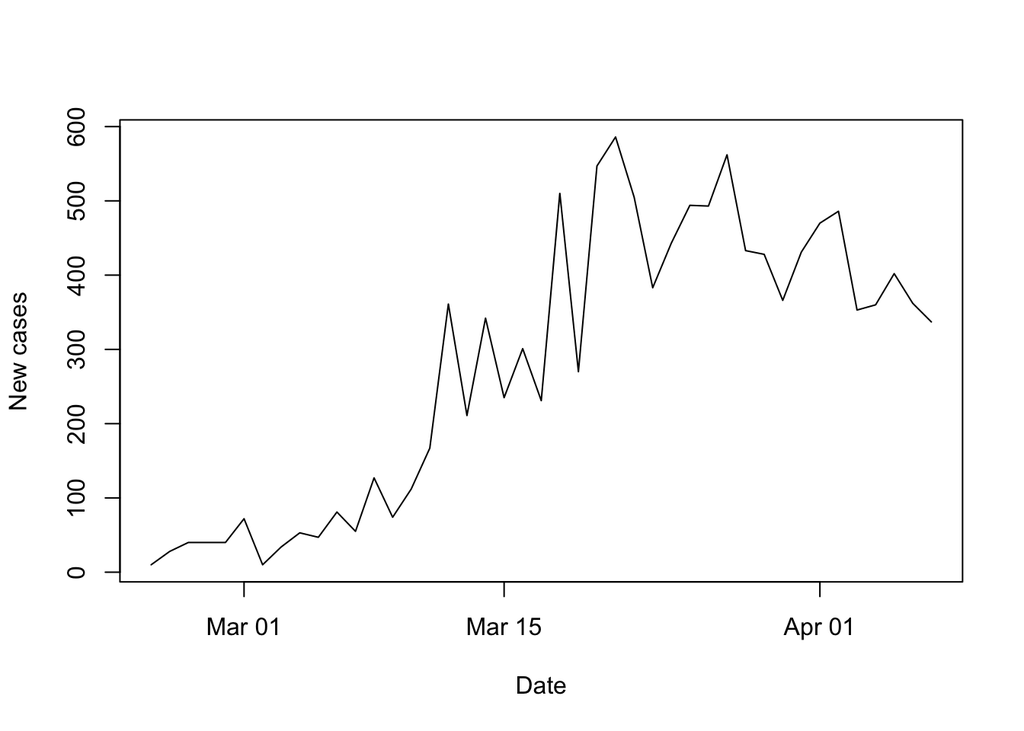

### The S(E)IR model (to be revised)

With the aim of predicting the future number of COVID19 cases on the basis of the actual data, we used a SEIR model applied to the COVID19 epidemic to the Veneto Region

We will consider the classical [SIR model](https://en.wikipedia.org/wiki/Compartmental_models_in_epidemiology) [@Kermack1927].

The model divides a population of hosts into three classes: susceptible, infected, recovered. The model describes how the portion of the population in each of these classes changes with time. Births are modeled as flows from “elsewhere” into the susceptible class; deaths are modeled as flows from the $S$, $I$, or $R$ compartment into “elsewhere”. If $S$, $I$, and $R$ refer to the numbers of individuals in each compartment, then these **state variables** change according to the following system of differential equations:
$$\begin{aligned}
\frac{d}{dt}S(t) &= B(t)-\lambda\,S(t)-\mu\,S(t)\\
\frac{d}{dt}I(t) &= \lambda\,S(t)-\gamma\,I(t)-\mu\,I(t)\\
\frac{d}{dt}R(t) &= \gamma\,I(t)-\mu\,R(t).\\
\end{aligned}$$
Here, $B$ is the crude birth rate (births per unit time), $\mu$ is the death rate and $\gamma$ is the recovery rate. We’ll assume that the force of infection, $\beta$, for a constant population $N$
$$\lambda = \beta\,\frac{I}{N},$$
so that the risk of infection a susceptible faces is proportional to the *prevalence* (the fraction of the population that is infected). This is known as the assumption of frequency-dependent transmission.

# The reproduction number of COVID19.

The number of infected individuals $I$ at time $t$ is approximately
$$I(t)\;\approx\;I_0\,e^{(R_0-1)\,(\gamma+\mu)\,t}$$
where $I_0$ is the (small) number of infectives at time $0$, $\frac{1}{\gamma}$ is the infectious period, and $\frac{1}{\mu}$ is the host lifespan.

$R_0$ is the reproduction number (https://en.wikipedia.org/wiki/Basic_reproduction_number) and indicates how contagious an infectious disease is.

Taking logs of both sides, we get

$$\log{I}(t)\;\approx\;\log{I_0}+(R_0-1)\,(\gamma+\mu)\,t,$$
which implies that a semi-log plot of $I$ vs $t$ should be approximately linear with a slope proportional to $R_0$ and the recovery rate.

[interactive chart not shown]

We estimate the $R_0$ parameter in the linear model.

$$\log(I(t))= \beta_0 + \beta_1 t +e_t.$$

The estimated slope coefficient $\hat\beta_1$ is used to estimate $R_0$ as in the following formula:

$$\widehat\beta_1=(\widehat{R_0}-1)\,(\gamma+\mu)$$
The parameter $\mu$<<$\gamma$ and it can not be considered. As consequence, R0 can be estimated as follows
$$\hat{R_0}=1+\frac{\hat{\beta_1}}{\gamma}$$
Respect to the SIR model, $R_0$ can be estimated as follows:
$$\hat{R_0}=\frac{\beta}{\gamma}$$
And this was we can retrive the value of $\beta$ in the SEIR model by means of
$$\hat{R_0}=\frac{\hat{\beta}}{\gamma}=1+\frac{\hat{\beta_1}}{\gamma}\\
\hat{\beta}=(1+\frac{\hat{\beta_1}}{\gamma})*{\gamma}={\gamma}+\hat{\beta}_1$$
where $\beta_1$ is the slope coefficient. \

The incubation period for the coronavirus is in mean 5.1 days with a range from 2-14 days. Please see https://www.worldometers.info/coronavirus/coronavirus-incubation-period/. However, the incubation period is used for epidemic diseases that causes the immediate home isolation of infected subjects. The duration of the diseases is about 2 weeks.

However, in the calculation of R0 we considered an infectious period of 18 days on the basis of recent publications (https://www.nature.com/articles/s41421-020-0148-0).

We calculate several R0 values, each one based on a mobile window of 5 days, that can be sufficient to estimate a local trend, in order to assess if the R0 trend is decreasing (how is expected to be). In this way, the R0 for the first and the last two days of observation is impossibile to estimate.

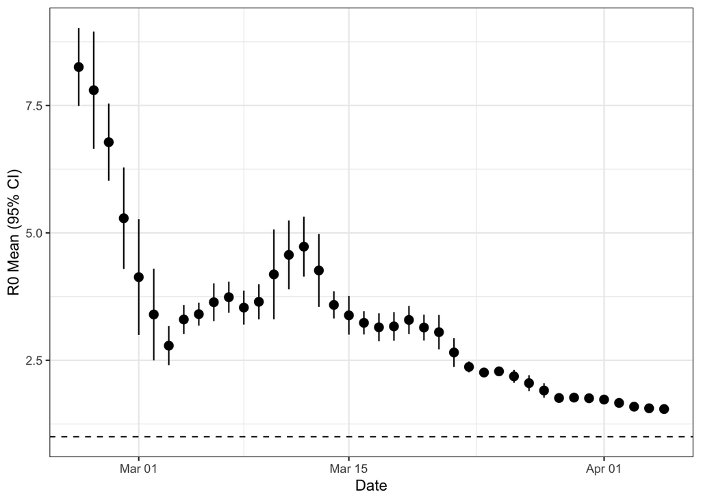

The R0 shows a decreasing trend in the last period. We use the estimated trend between R0 and time to calculate the future R0 value for the next 14 days. We predict beta (and R0) for the next 14 days by means of a linear regressione model, assuming a Log-Normal distribution for the the $\beta1$ and as consequence for the $\beta$ for the regression, rescaled of $1/\gamma$. We implement function to deal with log-normal distribution, in order to recover the parameter $\mu$ and $\sigma$ belonging normal distribution starting from this one:
$$\beta_{LogN}(t) \sim Log N (\beta_1(t)+\frac{1}{\gamma}, \sigma_{\beta_1(t)}^2)$$
In order to deal with estimations of $\hat\beta_1(t)$ that we have estimated before, we adopted an inverse transformation as reported here https://ocw.mit.edu/courses/civil-and-environmental-engineering/1-151-probability-and-statistics-in-engineering-spring-2005/lecture-notes/briefnts8_relnl.pdf. The following formulas provide us the mean and variance of the normal distribution

$$\beta_{N}(t) \sim N (\mu_{\beta_N},\sigma_{\beta_N}^2)$$
derived from the log-normal distribution $\beta_{LogN}(t)$.
$$\mu_{\beta_N} =e^{\mu_{\beta_{LogN}}+0.5*\sigma_{\beta_{LogN}}^2}$$

$$\sigma_{\beta_N}^2 =-2\log(\mu_{\beta_{LogN}})+\log(\mu_{\beta_{LogN}}^2+\sigma_{\beta_{LogN}}^2)$$
This transformation permits us to perform an inference based on the classical regression model for the predict forward of the future values of $\beta_{LogN}(t)$ with a direct transformation.

```
##
## Call:
## glm(formula = beta_norm ~ time, family = gaussian, data = data,
##     weights = 1/(sd_beta_norm)^2)
##
## Deviance Residuals:
##     Min       1Q   Median       3Q      Max
## -7.7317  -1.2874   0.9356   2.9659   7.3324
##
## Coefficients:
##              Estimate Std. Error t value Pr(>|t|)
## (Intercept) -1.022301   0.051449  -19.87   <2e-16 ***
## time        -0.035022   0.001541  -22.73   <2e-16 ***
## ---
## Signif. codes:  0 '***' 0.001 '**' 0.01 '*' 0.05 '.' 0.1 ' ' 1
##
## (Dispersion parameter for gaussian family taken to be 14.0055)
##
##     Null deviance: 7766.68  on 39  degrees of freedom
## Residual deviance:  532.21  on 38  degrees of freedom
## AIC: -43.745
##
## Number of Fisher Scoring iterations: 2
```

```
## Analysis of Deviance Table
##
## Model: gaussian, link: identity
##
## Response: beta_norm
##
## Terms added sequentially (first to last)
##
##
##      Df Deviance Resid. Df Resid. Dev  Pr(>Chi)
## NULL                    39     7766.7
## time  1   7234.5        38      532.2 < 2.2e-16 ***
## ---
## Signif. codes:  0 '***' 0.001 '**' 0.01 '*' 0.05 '.' 0.1 ' ' 1
```

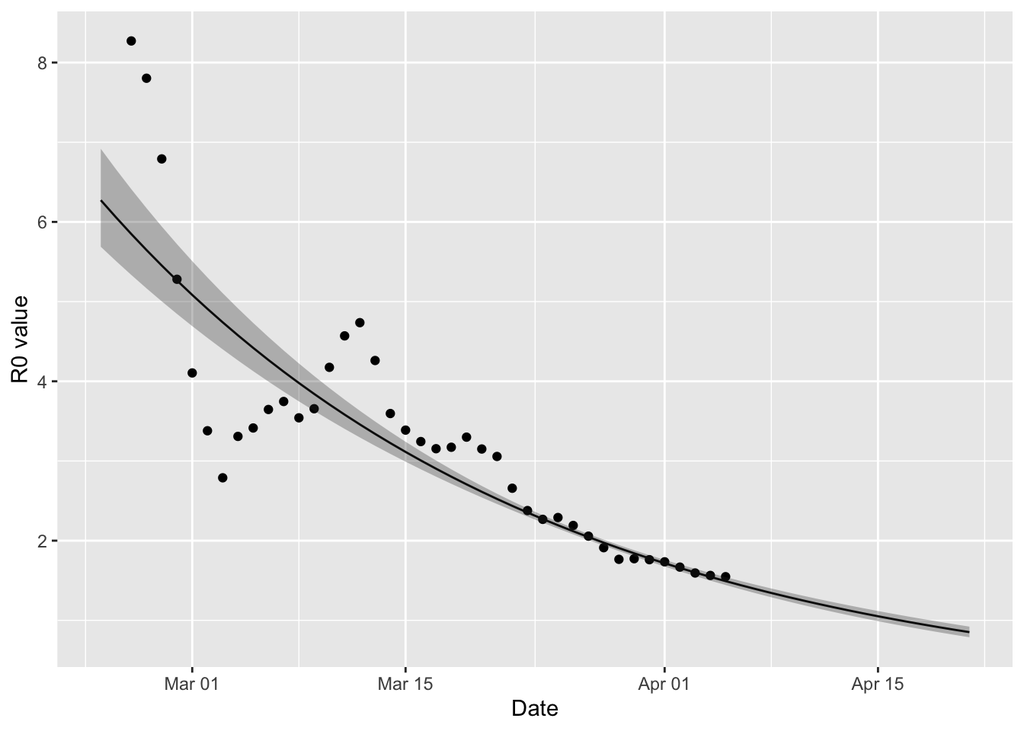

$$\begin{aligned}
\frac{d}{dt}S(t) &= \mu (N-S)-\beta \frac{SI}{N}-\nu S\\
\frac{d}{dt}E(t) &= \beta \frac{SI}{N}-(\mu+\sigma) E \\
\frac{d}{dt}I(t) &=\sigma E- (\mu+\gamma)I \\
\frac{d}{dt}R(t) &= \gamma\,I(t)-\mu\,R(t)+\nu S.\\
\end{aligned}$$

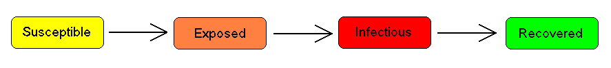

Respect to the previous formulation, the compartment of exposed people (E) was inserted between the susceptible and infected compartments.  
(https://en.wikipedia.org/wiki/Bayesian_structural_time_series). The parameter $\nu$ is the rate of vaccination.

We want to make a short term forecast (14 days).

We made a forecast by means of a SEIR model fixing a series of initial status:  
*S:N, the size of the Veneto Region population*  
E: The number of exposed people, but supposed to be at least 3 times the infected (3 x I_start)  
*I_start: initial number of COVID-19 cases*  
R_start: initial number of recovered

```r
# initial number of infectus
I_start<-dat_csv$totale_positivi[dim(dat_csv)[1]]; I_start
```

```
## [1] 9965
```

```r
# initial number of recovered, based on the proportion of discharged from the health services
prop<-dat_csv$dimessi_guariti[dim(dat_csv)[1]]/dat_csv$totale_ospedalizzati[dim(dat_csv)[1]]
R_start<-prop*dat_csv$totale_casi[dim(dat_csv)[1]]; R_start
```

```
## [1] 8041.111
```

```r
# Veneto population
N=4905864
#  duration of COVID19 diseases
duration<-18
#mortality rate
mu0<-1/(82*365.25) # 1/lifespan
```

We suppose that the number of total infected $I(t)$ can be the realization of a Poisson random variable
$$I(t) \sim Poisson (\theta_t)$$
where $\theta_t$ is the unknown mean of the random process at the time $t$.

The Poisson distribution has a fixed variance that is equal to the mean; in the next part we try to estimates the parameters considering a Negative Binomial distribution which allows for overdispersion.

However, the parameter $\theta_t$ can be supposed to be a realization of a SEIR model with initial parameters $\theta=(\mu,\beta,\sigma, \gamma)$ and initial status $S=(S_{start},E_{start},I_{start},R_{start})$.

The parameter $\sigma$ is our parameter of interest; we estimate $\sigma$ fixing $E_{start}= 3*I_{start}$ minimizing the log likelihood of the described Poisson distribution (or Negative Binomial one).

```r
# number of the last considered days for calibration
last<-10
#I_start
I_1<-dat_csv$totale_positivi[(days-last)]
#R_start
R_1<-prop*dat_csv$totale_casi[(days-last)]
#loglikelihood function
LogLikfun <- function (initials,parameters,obs) {
n<-length(obs)
N=4905864
seir_fit <- SEIR(pars = parameters, init = initials, time = 0:last)
#Poisson
sum(dpois(x=obs[-1],lambda = seir_fit$results$I[-1]*N,log=TRUE))
#Neg Binomial
#sum(dnbinom(x=obs[-1],mu=seir_fit$results$I[-1]*N,size=N,log=TRUE))
#SSE
#-sum((obs[-1]-seir_fit$results$I[-1]*N)^2)
}
### logit and its inverse for sigma
logit <- function (p) log(p/(1-p))    # the logit transform
expit <- function (x) 1/(1+exp(-x))   # inverse logit

f1<-function(par){
#max 0.20 according to https://www.nejm.org/doi/10.1056/NEJMoa2001316 is 1/5.2
sigma<-expit(par)
f_exp<-3*I_1/N
parameters <- c(mu = mu0, beta =(as.numeric(beta1[(days-last-2)])+1/duration), sigma = sigma, gamma =1/duration)
initials <- c(S = (1-(f_exp+I_1/N+R_start/N)), E = f_exp, I = I_1/N, R = R_1/N)
-LogLikfun(initials,parameters,dat_csv$totale_positivi[c((days-last):days)])
}
est<-optim(fn=f1,par=logit(0.1))
est
```

```
## $par
## [1] -3.269444
##
## $value
## [1] 55.93137
##
## $counts
## function gradient
##       30       NA
##
## $convergence
## [1] 0
##
## $message
## NULL
```

```r
expit(est$par)
```

```
## [1] 0.03663443
```

```r
f_exp<-3*I_1/N
sigma<-expit(est$par)

parameters <- c(mu = mu0, beta =(as.numeric(beta1[(days-last-2)])+1/duration), sigma = sigma, gamma = 1/duration)
initials <- c(S = (1-(f_exp+I_1/N+R_1/N)), E = f_exp, I = I_1/N, R = R_1/N)
pro<-SEIR(pars = parameters, init = initials, time = 0:last)
#predicted vs observed
cbind(pro$results$I*N,dat_csv$totale_positivi[c((days-last):days)])
```

```
##           [,1] [,2]
##  [1,] 6913.000 6913
##  [2,] 7278.078 7251
##  [3,] 7623.586 7564
##  [4,] 7951.848 7850
##  [5,] 8264.710 8224
##  [6,] 8564.425 8578
##  [7,] 8852.569 8861
##  [8,] 9130.654 9093
##  [9,] 9400.042 9409
## [10,] 9661.960 9722
## [11,] 9917.512 9965
```

The values of initial parameters are

```r
#mu0
mu0;
```

```
## [1] 3.338842e-05
```

```r
#sigma
sigma
```

```
## [1] 0.03663443
```

```r
#gamma
1/duration
```

```
## [1] 0.05555556
```

```r
#mthe unknowrn fraction of exposed people is
pro$results$E[last+1]
```

```
## [1] 0.004473631
```

```r
#that is
pro$results$E[last+1]/pro$results$I[last+1]
```

```
## [1] 2.212957
```

```r
#times the infected
```

# Forecast 1 - Results based on beta coefficient trend

For the beta parameter, we perfomed a simulation on its trend by means of a Bayesian Structural Time Series using the library bsts of R.  
We estimated a BSTS model specifing a local linear trend and a seasonality component. The model predicted 1000 trajectories forward of the beta coefficent.

We made a forecast forward of 14 days dropping the first 100 simulation as burn-in.

```r
# Bayesian Structural Time Series
#we assume beta ~ LN (mu_b,sigma_b)

#we drop the first 6 beta_norm
ss <- AddStudentLocalLinearTrend(list(), beta_norm[6:(days-4)])
ss <- AddSeasonal(ss, beta_norm[6:(days-4)], nseasons = 7)
model1 <- bsts(beta_norm[6:(days-4)],
               state.specification = ss,
               niter = 1000,seed=123)
```

[output not shown]

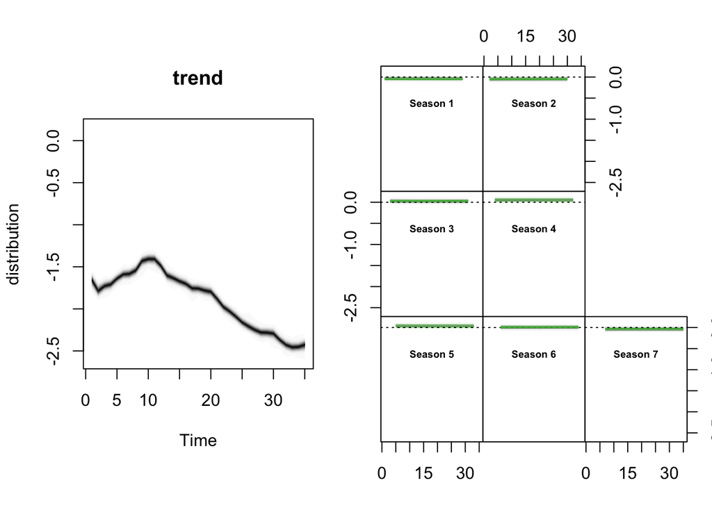

```r
par(mfrow = c(1,1))
plot(model1, "components")
```

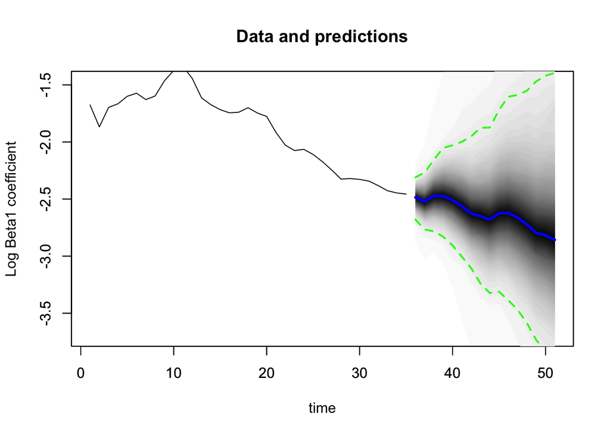

```r
#previsioni
pred1 <- predict(model1, horizon = 16, burn = 100)
plot(pred1 , ylab="Log Beta1 coefficient",main="Data and predictions",ylim=c(-3,3)*IQR(pred1$distribution)+median(pred1$distribution))
```

```r
# matrix of beta coefficients
coef<-M_from_Norm(pred1$distribution[,3:16],sd_norm_mean)
par(mfrow = c(1,1))
```

For each vector of simulated beta coefficients we perform a SEIR model. We save the results and plot a credible interval at 90% (5-95% percentile).

```r
seir1_sim<-NULL
for(s in 1:dim(coef)[1]){
  # average number of single connections of an infected person
  # less contacts, less probability of new infections
  # we keep constant the other parameters
  forecast<-14
  seir1<-NULL
  for(i in 1:forecast){
    parameters <- c(mu = mu0, beta = matrix(coef[s,i]), sigma = sigma, gamma = 1/duration)
    if( i==1) initials <- c(S = 1-(pro$results$E[last+1]+I_start/N+R_start/N), E = pro$results$E[last+1], I = I_start/N, R = R_start/N)
    if( i>1) initials <- c(S = seir1_temp$results$S[2], E = seir1_temp$results$E[2], I =seir1_temp$results$I[2], R = seir1_temp$results$R[2])
    seir1_temp <- SEIR(pars = parameters, init = initials, time = 0:1)
    seir1 <- rbind(seir1,SEIR(pars = parameters, init = initials, time = 0:1)$results[2,])
  }
  seir1_sim<-rbind(seir1_sim,cbind(rep(s,forecast),seir1))

}
seir1_sim[,2]<-rep(1:forecast,dim(coef)[1])
colnames(seir1_sim)[1]<-"sim"

### confidence limits
I_seir_med<-tapply(seir1_sim$I,seir1_sim$time,median)
I_seir_lwr<-tapply(seir1_sim$I,seir1_sim$time,quantile,p=0.05)
I_seir_upr<-tapply(seir1_sim$I,seir1_sim$time,quantile,p=0.95)

days.before<-date[1:days]
days.ahead<-date[(days+1):(days+forecast)]
step.ahead<-forecast+1
mu.lower<-c(dat_csv$totale_positivi,I_seir_lwr*N)
mu.upper<-c(dat_csv$totale_positivi,I_seir_upr*N)
mu.med<-xts(c(dat_csv$totale_positivi,I_seir_med*N),order.by = c(days.before,days.ahead),frequency = 7)
counts<-mu.med
mu<-xts(x = as.matrix(cbind(counts,mu.lower,mu.upper)) , order.by = c(days.before,days.ahead))
p <- dygraph(mu,main=paste("Veneto Region: Scenario 1 (Credible Interval ",100*0.90,"%)",sep = ""),ylab=" Infected",xlab="Day",height=400,width=800) %>%  dySeries(c("mu.lower", "counts", "mu.upper"),label="counts")
p<-p %>% dyLegend(show = "always", hideOnMouseOut = FALSE) %>%  dyShading(from = days.ahead[1], to = days.ahead[step.ahead], color = "#CCEBD6")%>% dyEvent(days.ahead[1], "Prediction", labelLoc = "bottom")
p
```

[interactive chart not shown]

The estimated (median) numbers of the current scenario by date are:

```r
S_seir_med<-tapply(seir1_sim$S,seir1_sim$time,median)
E_seir_med<-tapply(seir1_sim$E,seir1_sim$time,median)
R_seir_med<-tapply(seir1_sim$R,seir1_sim$time,median)
forecast<-data.frame(S_seir_med,E_seir_med,I_seir_med,R_seir_med)*N
colnames(forecast)<-c("Susceptible","Exposed","Infected","Removed")
rownames(forecast)<-days.ahead
kable(forecast)
```

|  | Susceptible | Exposed | Infected | Removed |
| --- | --- | --- | --- | --- |
| 2020-04-08 | 4865064 | 21989.54 | 10209.07 | 8601.225 |
| 2020-04-09 | 4864205 | 22043.70 | 10441.54 | 9174.559 |
| 2020-04-10 | 4863351 | 22091.19 | 10662.79 | 9760.486 |
| 2020-04-11 | 4862509 | 22117.27 | 10873.67 | 10358.347 |
| 2020-04-12 | 4861733 | 22089.46 | 11074.48 | 10967.579 |
| 2020-04-13 | 4860941 | 22067.88 | 11262.57 | 11587.728 |
| 2020-04-14 | 4860175 | 22036.30 | 11439.57 | 12218.046 |
| 2020-04-15 | 4859340 | 22059.96 | 11606.23 | 12857.565 |
| 2020-04-16 | 4858493 | 22092.07 | 11763.44 | 13506.614 |
| 2020-04-17 | 4857685 | 22080.26 | 11918.88 | 14164.078 |
| 2020-04-18 | 4856925 | 22067.45 | 12060.34 | 14829.463 |
| 2020-04-19 | 4856178 | 21980.18 | 12197.20 | 15502.634 |
| 2020-04-20 | 4855429 | 21897.58 | 12318.69 | 16182.909 |
| 2020-04-21 | 4854739 | 21841.13 | 12425.34 | 16869.140 |

# Scenario 2 - Forecast based on the last beta coefficient

We estimate a second scenario using a Random Walk on the basis of the last value of the beta.

```r
ss<-NULL
set.seed(123)
#we assum log_beta ~ N()
ss <-   AddLocalLevel(, beta_norm[(days-9):(days-4)],sdy=sd_norm_mean)
model1 <- bsts(beta_norm[(days-9):(days-4)],
               state.specification = ss,
               niter = 1000,seed=123)
```

[output not shown]

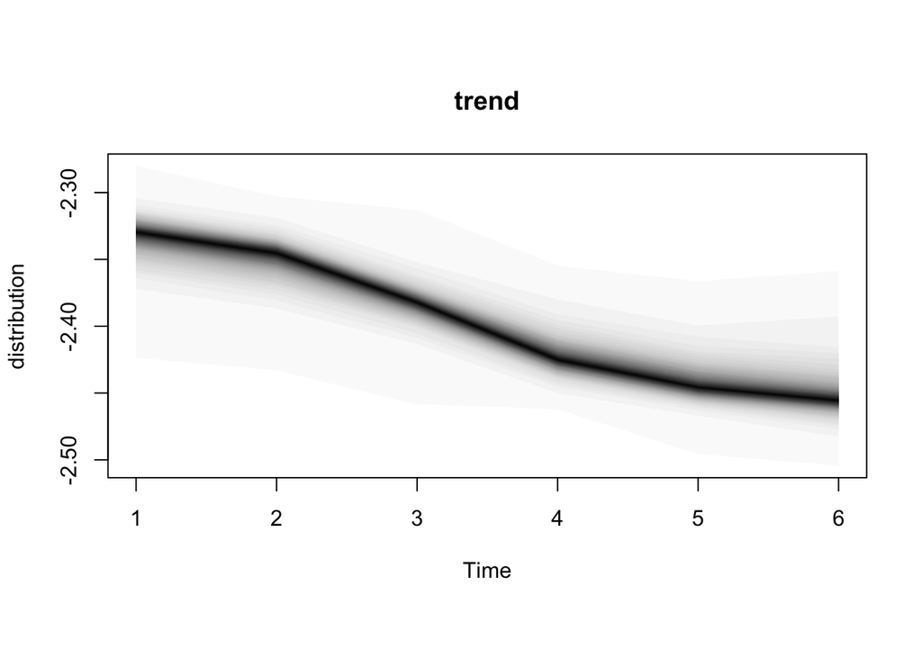

```r
par(mfrow = c(1,1))
plot(model1, "components")
```

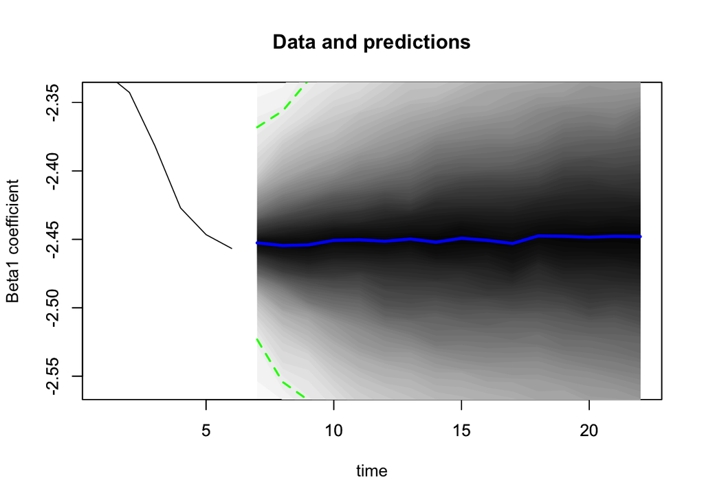

```r
#previsioni
pred1 <- predict(model1, horizon = 16, burn = 100)
par(mfrow = c(1,1))
plot(pred1 , ylab="Beta1 coefficient",main="Data and predictions",ylim=c(-1,1)*IQR(pred1$distribution)+median(pred1$distribution))
```

```r
# matrix of beta coefficients
coef<-M_from_Norm(pred1$distribution[,3:16],sd_norm_mean)
par(mfrow = c(1,1))

seir2_sim<-NULL
for(s in 1:dim(coef)[1]){
  # average number of single connections of an infected person
  # less contacts, less probability of new infections
  # we keep constant the other parameters
  forecast<-14
  seir2<-NULL
  for(i in 1:forecast){
    parameters <- c(mu = mu0, beta = (matrix(coef[s,i])+1/duration), sigma = sigma, gamma = 1/duration)
    if( i==1) initials <- c(S = 1-(pro$results$E[last+1]+I_start/N+R_start/N), E = pro$results$E[last+1], I = I_start/N, R = R_start/N)
    if( i>1) initials <- c(S = seir2_temp$results$S[2], E = seir2_temp$results$E[2], I =seir2_temp$results$I[2], R = seir2_temp$results$R[2])
    seir2_temp <- SEIR(pars = parameters, init = initials, time = 0:1)
    seir2 <- rbind(seir2,SEIR(pars = parameters, init = initials, time = 0:1)$results[2,])
  }
  seir2_sim<-rbind(seir2_sim,cbind(rep(s,forecast),seir2))

}
seir2_sim[,2]<-rep(1:forecast,dim(coef)[1])
colnames(seir2_sim)[1]<-"sim"

### confidence limits
I_seir_med<-tapply(seir2_sim$I,seir2_sim$time,median)
I_seir_lwr<-tapply(seir2_sim$I,seir2_sim$time,quantile,p=0.05)
I_seir_upr<-tapply(seir2_sim$I,seir2_sim$time,quantile,p=0.95)

days.before<-date[1:days]
days.ahead<-date[(days+1):(days+forecast)]
step.ahead<-forecast+1
mu.lower<-c(dat_csv$totale_positivi,I_seir_lwr*N)
mu.upper<-c(dat_csv$totale_positivi,I_seir_upr*N)
mu.med<-xts(c(dat_csv$totale_positivi,I_seir_med*N),order.by = c(days.before,days.ahead),frequency = 7)
counts<-mu.med
mu<-xts(x = as.matrix(cbind(counts,mu.lower,mu.upper)) , order.by = c(days.before,days.ahead))
p <- dygraph(mu,main=paste("Veneto Region: Scenario 2 (Credible Interval ",100*0.90,"%)",sep = ""),ylab=" Infected",xlab="Day",height=400,width=800) %>%  dySeries(c("mu.lower", "counts", "mu.upper"),label="counts")
p<-p %>% dyLegend(show = "always", hideOnMouseOut = FALSE) %>%  dyShading(from = days.ahead[1], to = days.ahead[step.ahead], color = "#CCEBD6")%>% dyEvent(days.ahead[1], "Prediction", labelLoc = "bottom")
p
```

[interactive chart not shown]

The estimated (median) numbers of the second scenario by date are:

```r
S_seir_med<-tapply(seir2_sim$S,seir2_sim$time,median)
E_seir_med<-tapply(seir2_sim$E,seir2_sim$time,median)
R_seir_med<-tapply(seir2_sim$R,seir2_sim$time,median)
forecast<-data.frame(S_seir_med,E_seir_med,I_seir_med,R_seir_med)*N
colnames(forecast)<-c("Susceptible","Exposed","Infected","Removed")
rownames(forecast)<-days.ahead
kable(forecast)
```

|  | Susceptible | Exposed | Infected | Removed |
| --- | --- | --- | --- | --- |
| 2020-04-08 | 4864493 | 22550.13 | 10219.06 | 8601.502 |
| 2020-04-09 | 4863037 | 23169.41 | 10481.16 | 9176.211 |
| 2020-04-10 | 4861544 | 23802.39 | 10751.34 | 9765.688 |
| 2020-04-11 | 4860014 | 24450.39 | 11029.90 | 10370.383 |
| 2020-04-12 | 4858436 | 25116.76 | 11316.96 | 10990.776 |
| 2020-04-13 | 4856820 | 25806.35 | 11612.33 | 11627.303 |
| 2020-04-14 | 4855164 | 26504.66 | 11917.12 | 12280.535 |
| 2020-04-15 | 4853454 | 27226.79 | 12229.25 | 12950.920 |
| 2020-04-16 | 4851713 | 27954.87 | 12550.46 | 13639.029 |
| 2020-04-17 | 4849932 | 28703.76 | 12882.90 | 14344.997 |
| 2020-04-18 | 4848091 | 29486.70 | 13225.27 | 15069.603 |
| 2020-04-19 | 4846205 | 30270.94 | 13575.27 | 15813.312 |
| 2020-04-20 | 4844260 | 31094.43 | 13934.67 | 16576.908 |
| 2020-04-21 | 4842280 | 31908.54 | 14303.09 | 17361.469 |

# Number of admitted in intensive care

The number of person admitted in intensive care repart is a fraction of the COVID 19 case. The trend can be estimated by means a binomial regression model.  
We report the number of intensive care patients on the basis of the estimated COVID19 cases of the previous scenario 1 and 2.

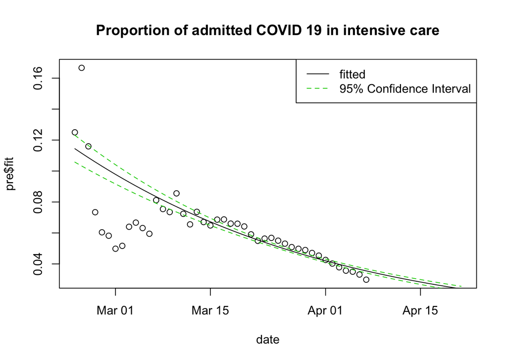

```r
fit_int_care<-glm(cbind(terapia_intensiva,totale_positivi-terapia_intensiva)~t,family=binomial,data=dat_csv)




forecast=14
# add 'fit', 'lwr', and 'upr' columns to dataframe (generated by predict)
pre<-predict(fit_int_care,type='response',newdata=data.frame(t=1:(days+forecast)),se.fit=TRUE)
date<-seq(as.Date("2020-02-24"),as.Date("2020-02-24")+forecast-1+dim(dat_csv)[1],1)
plot(date,pre$fit,type="l",main="Proportion of admitted COVID 19 in intensive care",ylim=range(dat_csv$terapia_intensiva/dat_csv$totale_positivi))
points(date[1:days],dat_csv$terapia_intensiva/dat_csv$totale_positivi)
lines(date,pre$fit+1.96*pre$se.fit,col=3,lty=2)
lines(date,pre$fit-1.96*pre$se.fit,col=3,lty=2)
legend("topright",c("fitted","95% Confidence Interval"),lty=1:2,col=c(1,3))
```

```r
days.before<-date[1:days]
days.ahead<-date[(days+1):(days+forecast)]
step.ahead<-forecast+1


#Scenario 1

I_seir_med<-tapply(seir1_sim$I,seir1_sim$time,median)
I_seir_lwr<-tapply(seir1_sim$I,seir1_sim$time,quantile,p=0.05)
I_seir_upr<-tapply(seir1_sim$I,seir1_sim$time,quantile,p=0.75)

mu.lower<-c(dat_csv$terapia_intensiva,I_seir_med*N*((pre$fit-1.645*pre$se.fit)[(days+1):(days+forecast)]))
mu.upper<-c(dat_csv$terapia_intensiva,I_seir_med*N*((pre$fit+1.645*pre$se.fit)[(days+1):(days+forecast)]))
mu.med<-xts(c(dat_csv$terapia_intensiva,I_seir_med*N*((pre$fit)[(days+1):(days+forecast)])),order.by = c(days.before,days.ahead),frequency = 7)
counts<-mu.med
mu<-xts(x = as.matrix(cbind(counts,mu.lower,mu.upper)) , order.by = c(days.before,days.ahead))
p <- dygraph(mu,main=paste("Veneto Region: Scenario 1 (Confidence Interval ",100*0.90,"%)",sep = ""),ylab=" Infected",xlab="Day",height=400,width=800) %>%  dySeries(c("mu.lower", "counts", "mu.upper"),label="counts")
p<-p %>% dyLegend(show = "always", hideOnMouseOut = FALSE) %>%  dyShading(from = days.ahead[1], to = days.ahead[step.ahead], color = "#CCEBD6")%>% dyEvent(days.ahead[1], "Prediction", labelLoc = "bottom")
p
```

[interactive chart not shown]

```r
#Numbers
intensive_care<-data.frame(mu.med,mu.lower,mu.upper)[(days+1):(days+forecast),]
kable(intensive_care)
```

|  | mu.med | mu.lower | mu.upper |
| --- | --- | --- | --- |
| 2020-04-08 | 352.1803 | 340.4554 | 363.9053 |
| 2020-04-09 | 350.1756 | 337.8755 | 362.4756 |
| 2020-04-10 | 347.6342 | 334.7723 | 360.4960 |
| 2020-04-11 | 344.6246 | 331.2168 | 358.0325 |
| 2020-04-12 | 341.1937 | 327.2582 | 355.1293 |
| 2020-04-13 | 337.2962 | 322.8574 | 351.7350 |
| 2020-04-14 | 333.0189 | 318.1014 | 347.9364 |
| 2020-04-15 | 328.4169 | 313.0461 | 343.7877 |
| 2020-04-16 | 323.5440 | 307.7457 | 339.3423 |
| 2020-04-17 | 318.6318 | 302.4225 | 334.8411 |
| 2020-04-18 | 313.3707 | 296.7844 | 329.9571 |
| 2020-04-19 | 308.0312 | 291.0898 | 324.9726 |
| 2020-04-20 | 302.3612 | 285.1020 | 319.6204 |
| 2020-04-21 | 296.4063 | 278.8666 | 313.9460 |

```r
#Scenario 2

I_seir_med<-tapply(seir2_sim$I,seir2_sim$time,median)
I_seir_lwr<-tapply(seir2_sim$I,seir2_sim$time,quantile,p=0.25)
I_seir_upr<-tapply(seir2_sim$I,seir2_sim$time,quantile,p=0.75)

mu.lower<-c(dat_csv$terapia_intensiva,I_seir_med*N*((pre$fit-1.645*pre$se.fit)[(days+1):(days+forecast)]))
mu.upper<-c(dat_csv$terapia_intensiva,I_seir_med*N*((pre$fit+1.645*pre$se.fit)[(days+1):(days+forecast)]))
mu.med<-xts(c(dat_csv$terapia_intensiva,I_seir_med*N*((pre$fit)[(days+1):(days+forecast)])),order.by = c(days.before,days.ahead),frequency = 7)
counts<-mu.med
mu<-xts(x = as.matrix(cbind(counts,mu.lower,mu.upper)) , order.by = c(days.before,days.ahead))
p <- dygraph(mu,main=paste("Veneto Region: Scenario 2 (Confidence Interval ",100*0.9,"%)",sep = ""),ylab=" Infected",xlab="Day",height=400,width=800) %>%  dySeries(c("mu.lower", "counts", "mu.upper"),label="counts")
p<-p %>% dyLegend(show = "always", hideOnMouseOut = FALSE) %>%  dyShading(from = days.ahead[1], to = days.ahead[step.ahead], color = "#CCEBD6")%>% dyEvent(days.ahead[1], "Prediction", labelLoc = "bottom")
p
```

[interactive chart not shown]

```r
#Numbers
intensive_care<-data.frame(mu.med,mu.lower,mu.upper)[(days+1):(days+forecast),]
kable(intensive_care)
```

|  | mu.med | mu.lower | mu.upper |
| --- | --- | --- | --- |
| 2020-04-08 | 352.5250 | 340.7886 | 364.2614 |
| 2020-04-09 | 351.5043 | 339.1576 | 363.8510 |
| 2020-04-10 | 350.5213 | 337.5526 | 363.4900 |
| 2020-04-11 | 349.5763 | 335.9758 | 363.1769 |
| 2020-04-12 | 348.6641 | 334.4235 | 362.9048 |
| 2020-04-13 | 347.7708 | 332.8836 | 362.6580 |
| 2020-04-14 | 346.9209 | 331.3806 | 362.4612 |
| 2020-04-15 | 346.0461 | 329.8502 | 362.2420 |
| 2020-04-16 | 345.1904 | 328.3351 | 362.0457 |
| 2020-04-17 | 344.4033 | 326.8829 | 361.9236 |
| 2020-04-18 | 343.6397 | 325.4513 | 361.8281 |
| 2020-04-19 | 342.8334 | 323.9778 | 361.6889 |
| 2020-04-20 | 342.0252 | 322.5019 | 361.5485 |
| 2020-04-21 | 341.1999 | 321.0096 | 361.3903 |